# Foundations for statistical inference - Confidence intervals

Emmanuel Kasigazi

If you have access to data on an entire population, say the opinion of every adult in the United States on whether or not they think climate change is affecting their local community, it’s straightforward to answer questions like, “What percent of US adults think climate change is affecting their local community?”. Similarly, if you had demographic information on the population you could examine how, if at all, this opinion varies among young and old adults and adults with different leanings. If you have access to only a sample of the population, as is often the case, the task becomes more complicated. What is your best guess for this proportion if you only have data from a small sample of adults? This type of situation requires that you use your sample to make inference on what your population looks like.

**Setting a seed:** You will take random samples and build sampling distributions in this lab, which means you should set a seed on top of your lab. If this concept is new to you, review the lab on probability.

## Getting Started

### Load packages

In this lab, we will explore and visualize the data using the **tidyverse** suite of packages, and perform statistical inference using **infer**.

Let’s load the packages.

```r
library(tidyverse)
library(openintro)
library(infer)
library(infer)
library(dplyr)
library(tinytex)
```

### The data

A 2019 Pew Research report states the following:

To keep our computation simple, we will assume a total population size of 100,000 (even though that’s smaller than the population size of all US adults).

> Roughly six-in-ten U.S. adults (62%) say climate change is currently affecting their local community either a great deal or some, according to a new Pew Research Center survey.

> **Source:** [Most Americans say climate change impacts their community, but effects vary by region](https://www.pewresearch.org/fact-tank/2019/12/02/most-americans-say-climate-change-impacts-their-community-but-effects-vary-by-region/)

In this lab, you will assume this 62% is a true population proportion and learn about how sample proportions can vary from sample to sample by taking smaller samples from the population. We will first create our population assuming a population size of 100,000. This means 62,000 (62%) of the adult population think climate change impacts their community, and the remaining 38,000 does not think so.

```r
us_adults <- tibble(
  climate_change_affects = c(rep("Yes", 62000), rep("No", 38000))
)
```

The name of the data frame is `us_adults` and the name of the variable that contains responses to the question *“Do you think climate change is affecting your local community?”* is `climate_change_affects`.

We can quickly visualize the distribution of these responses using a bar plot.

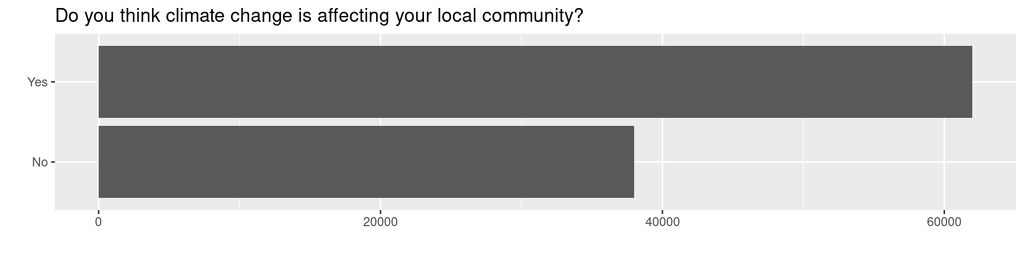

```r
ggplot(us_adults, aes(x = climate_change_affects)) +
  geom_bar() +
  labs(
    x = "", y = "",
    title = "Do you think climate change is affecting your local community?"
  ) +
  coord_flip()
```

We can also obtain summary statistics to confirm we constructed the data frame correctly.

```r
us_adults %>%
  count(climate_change_affects) %>%
  mutate(p = n /sum(n))
```

```
## # A tibble: 2 × 3
##   climate_change_affects     n     p
##   <chr>                  <int> <dbl>
## 1 No                     38000  0.38
## 2 Yes                    62000  0.62
```

In this lab, you’ll start with a simple random sample of size 60 from the population.

```r
n <- 60
samp <- us_adults %>%
  sample_n(size = n)
```

1. What percent of the adults in your sample think climate change affects their local community? **Hint:** Just like we did with the population, we can calculate the proportion of those **in this sample** who think climate change affects their local community.

```r
samp %>%
  count(climate_change_affects) %>%
  mutate(p = n /sum(n))
```

```
## # A tibble: 2 × 3
##   climate_change_affects     n     p
##   <chr>                  <int> <dbl>
## 1 No                        21  0.35
## 2 Yes                       39  0.65
```

[output not shown]

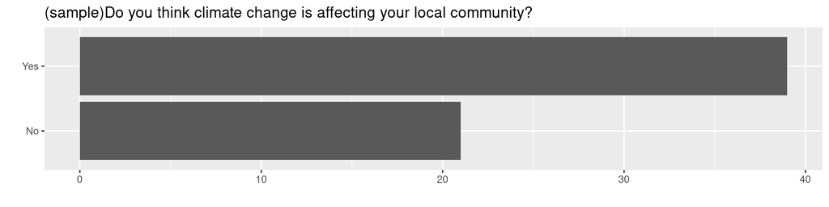

```r
ggplot(samp, aes(x = climate_change_affects)) +
  geom_bar() +
  labs(
    x = "", y = "",
    title = "(sample)Do you think climate change is affecting your local community?"
  ) +
  coord_flip()
```

1. Would you expect another student’s sample proportion to be identical to yours? Would you expect it to be similar? Why or why not?

**Not exactly similar in terms of figures, but they should have nearly the same proportions because we are sampling from the same population.**

## Confidence intervals

Return for a moment to the question that first motivated this lab: based on this sample, what can you infer about the population? With just one sample, the best estimate of the proportion of US adults who think climate change affects their local community would be the sample proportion, usually denoted as $\hat{p}$ (here we are calling it `p_hat`). That serves as a good **point estimate**, but it would be useful to also communicate how uncertain you are of that estimate. This uncertainty can be quantified using a **confidence interval**.

One way of calculating a confidence interval for a population proportion is based on the Central Limit Theorem, as $\hat{p} \pm z^\star SE_{\hat{p}}$ is, or more precisely, as
$$\hat{p} \pm z^\star
\sqrt{ \frac{\hat{p} (1-\hat{p})}{n} }$$

Another way is using simulation, or to be more specific, using **bootstrapping**. The term **bootstrapping** comes from the phrase “pulling oneself up by one’s bootstraps”, which is a metaphor for accomplishing an impossible task without any outside help. In this case the impossible task is estimating a population parameter (the unknown population proportion), and we’ll accomplish it using data from only the given sample. Note that this notion of saying something about a population parameter using only information from an observed sample is the crux of statistical inference, it is not limited to bootstrapping.

In essence, bootstrapping assumes that there are more of observations in the populations like the ones in the observed sample. So we “reconstruct” the population by resampling from our sample, with replacement. Bootstrapping is particularly useful when the sampling distribution of the statistic is unknown or difficult to derive theoretically. The bootstrapping scheme is as follows:

- **Step 1.** Take a bootstrap sample - a random sample taken **with replacement** from the original sample, of the same size as the original sample.With relacement. So even though you’re taking a sample of the same size, you’re not getting the exact same data because: Some values might appear multiple times.Some values might not appear at all
- **Step 2.** Calculate the bootstrap statistic - a statistic such as mean, median, proportion, slope, etc. computed on the bootstrap samples. This can indeed be any statistic of interest
- **Step 3.** Repeat steps (1) and (2) many times to create a bootstrap distribution - a distribution of bootstrap statistics. The process is repeated many times (typically 1000+ times) to create the bootstrap distribution.
- **Step 4.** Calculate the bounds of the XX% confidence interval as the middle XX% of the bootstrap distribution. Calculate the confidence interval bounds by finding the appropriate percentiles of the bootstrap distribution. For example, for a 95% confidence interval, you would use the 2.5th and 97.5th percentiles.

Instead of coding up each of these steps, we will construct confidence intervals using the **infer** package.

Below is an overview of the functions we will use to construct this confidence interval:

[output not shown]

This code will find the 95 percent confidence interval for proportion of US adults who think climate change affects their local community.

```r
samp %>%
  specify(response = climate_change_affects, success = "Yes") %>%
  generate(reps = 1000, type = "bootstrap") %>%
  calculate(stat = "prop") %>%
  get_ci(level = 0.95)
```

```
## # A tibble: 1 × 2
##   lower_ci upper_ci
##      <dbl>    <dbl>
## 1    0.533    0.767
```

- In `specify` we specify the `response` variable and the level of that variable we are calling a `success`.
- In `generate` we provide the number of resamples we want from the population in the `reps` argument (this should be a reasonably large number) as well as the type of resampling we want to do, which is `"bootstrap"` in the case of constructing a confidence interval.
- Then, we `calculate` the sample statistic of interest for each of these resamples, which is `prop`ortion.

Feel free to test out the rest of the arguments for these functions, since these commands will be used together to calculate confidence intervals and solve inference problems for the rest of the semester. But we will also walk you through more examples in future chapters.

To recap: even though we don’t know what the full population looks like, we’re 95% confident that the true proportion of US adults who think climate change affects their local community is between the two bounds reported as result of this pipeline.

## Confidence levels

1. In the interpretation above, we used the phrase “95% confident”. What does “95% confidence” mean?

   **We are relying on method hat will most likely produce the same same results in the long run: The 95% refers to how often the method works across many uses, not to any single use. We used a method (the bootstrap and 95% confidence level) that, in the long run, produces intervals that capture the true population proportion about 95% of the time.**

In this case, you have the rare luxury of knowing the true population proportion (62%) since you have data on the entire population.

1. Does your confidence interval capture the true population proportion of US adults who think climate change affects their local community? If you are working on this lab in a classroom, does your neighbor’s interval capture this value?

   **? If we know the true population, then yes, the confidence interval should capture the entire population. There’s a good chance this interval captures the true population proportion of 62%.**
2. Each student should have gotten a slightly different confidence interval. What proportion of those intervals would you expect to capture the true population mean? Why?

**95% of the intervals would be expected to capture the true population proportion (62% in this case) Here’s why:**

**By definition, a 95% confidence interval means that if we repeated this sampling and interval construction process many times, about 95% of the intervals would contain the true population parameter.**

**In this case: Each student is taking a different random sample of n=60 from the same population. Each student is using that sample to construct a 95% confidence interval using the same bootstrap method. Each interval will likely be different because:Their initial samples of 60 are different.Their 1000 bootstrap resamples are different**

**If we collected all these intervals: About 95% of them should contain 0.62 (the true proportion). About 5% would miss the true proportion (either falling entirely above or below 0.62). The 95% refers to the long-run success rate of the method, not the probability that any single interval contains the true proportion**.

In the next part of the lab, you will collect many samples to learn more about how sample proportions and confidence intervals constructed based on those samples vary from one sample to another.

- Obtain a random sample.
- Calculate the sample proportion, and use these to calculate and store the lower and upper bounds of the confidence intervals.
- Repeat these steps 50 times.

1. Given a sample size of 60, 1000 bootstrap samples for each interval, and 50 confidence intervals constructed (the default values for the above app), what proportion of your confidence intervals include the true population proportion? Is this proportion exactly equal to the confidence level? If not, explain why. Make sure to include your plot in your answer.

```r
library(here)
#knitr::include_graphics(here("05_foundations_for_inference", "1.png"))
```

**Failed to attach the images, tried all means, must be because i use Linux Mint. anyway I ran it a few times and used two images**

**Why the difference?**

**Random variation: With only 50 intervals, we don’t expect to see exactly 95% capture rate. Just like flipping a coin 50 times won’t always give exactly 25 heads. Three sources of randomness here:**

**Each original sample of 60 is random Each set of 1000 bootstrap samples is random We only have 50 intervals (small number of replications)**

**If we were to construct many more intervals (say 10,000 instead of 50), the proportion would likely be closer to 95%. The 95% confidence level is a long-run frequency interpretation - if we repeated this process infinitely many times, about 95% of intervals would contain the true proportion. In any finite sample of intervals, like our 50 here, we expect some deviation from exactly 95%**

## More Practice

1. Choose a different confidence level than 95%. Would you expect a confidence interval at this level to me wider or narrower than the confidence interval you calculated at the 95% confidence level? Explain your reasoning.

**Why this happens: 1. Higher confidence (like 99% or 98%): - Needs to “catch” the true parameter more often - Must be wider to have a higher chance of containing the true value - Trades precision for confidence**

2. **Lower confidence (like 45% or 20%):**
   - **Accepts missing the true parameter more often**
   - **Can be narrower since it doesn’t need to capture the parameter as frequently**
   - **Trades confidence for precision**

**Am personally Thinking of it like a net:**

**- A wide net (high confidence level) catches more fish but is less precise**

**- A narrow net (low confidence level) is more precise but misses more fish**

**This pattern illustrates the fundamental trade-off in confidence intervals: higher confidence requires wider intervals, while narrower intervals come with lower confidence.**

1. Using code from the **infer** package and data fromt the one sample you have (`samp`), find a confidence interval for the proportion of US Adults who think climate change is affecting their local community with a confidence level of your choosing (other than 95%) and interpret it.

```r
# Using the infer package for a 90% confidence interval
samp %>%
  specify(response = climate_change_affects, success = "Yes") %>%
  generate(reps = 1000, type = "bootstrap") %>%
  calculate(stat = "prop") %>%
  get_ci(level = 0.90)  # Changed from 0.95 to 0.90
```

```
## # A tibble: 1 × 2
##   lower_ci upper_ci
##      <dbl>    <dbl>
## 1     0.55     0.75
```

**This 90% confidence interval for the proportion of US adults who think climate change affects their local community is (0.55, 0.75) or between 55% and 75%. A few observations:**

**The true population proportion (0.62 or 62%) is contained within this interval.**

**The interval width is 0.75 - 0.55 = 0.20 (or 20 percentage points)**

**This interval is likely narrower than a 95% confidence interval would be for the same data, since:**

**A 90% confidence level means we’re willing to be “wrong” 10% of the time (vs 5% for a 95% CI)**

**This allows us to create a more precise (narrower) interval But we have less confidence that this interval contains the true population proportion**

1. Using the app, calculate 50 confidence intervals at the confidence level you chose in the previous question, and plot all intervals on one plot, and calculate the proportion of intervals that include the true population proportion. How does this percentage compare to the confidence level selected for the intervals?

**Still failing to attach images , but Counting the intervals:**

**Calculating capture percentage:**

**This is a great demonstration of what a confidence level means in practice:**

**We set our confidence level at 90% We constructed 50 different intervals About 90% of them (45) captured the true population proportion About 10% of them (5) missed it**

**The observed capture rate (90%) aligns remarkably well with the chosen confidence level (90%) in this case. However, it’s important to note:**

**This close match is somewhat lucky - with only 50 intervals, we could easily see more variation In the long run (with many more intervals), we’d expect the capture rate to converge to 90% Each individual interval still either contains or doesn’t contain the true proportion - the 90% refers to the long-run behavior of the method**

1. Lastly, try one more (different) confidence level. First, state how you expect the width of this interval to compare to previous ones you calculated. Then, calculate the bounds of the interval using the **infer** package and data from `samp` and interpret it. Finally, use the app to generate many intervals and calculate the proportion of intervals that are capture the true population proportion.

   ```r
   # Using the infer package for a 80% confidence interval
   samp %>%
     specify(response = climate_change_affects, success = "Yes") %>%
     generate(reps = 1000, type = "bootstrap") %>%
     calculate(stat = "prop") %>%
     get_ci(level = 0.80)  # Changed from 0.90 to 0.80
   ```

   ```
   ## # A tibble: 1 × 2
   ##   lower_ci upper_ci
   ##      <dbl>    <dbl>
   ## 1    0.567    0.717
   ```

   **Expected width comparison: An 80% confidence interval should be narrower than both the 95% and 90% intervals we calculated earlier. This is because with lower confidence (80%), we’re willing to be “wrong” more often (20% of the time), allowing us to make more precise (narrower) estimates**

1. Using the app, experiment with different sample sizes and comment on how the widths of intervals change as sample size changes (increases and decreases). **Higher confidence intervals are wider because they need to capture the true parameter more often—like using a wide net to catch more fish. In contrast, lower confidence intervals are narrower (more precise), but they’re more likely to miss the true value. This illustrates the trade-off: as you increase confidence, you sacrifice precision, and vice versa.**

1. Finally, given a sample size (say, 60), how does the width of the interval change as you increase the number of bootstrap samples. **Hint:** Does changing the number of bootstap samples affect the standard error?

```r
# With 100 resamples
samp %>%
  specify(response = climate_change_affects, success = "Yes") %>%
  generate(reps = 100, type = "bootstrap") %>%
  calculate(stat = "prop") %>%
  get_ci(level = 0.95)
```

```
## # A tibble: 1 × 2
##   lower_ci upper_ci
##      <dbl>    <dbl>
## 1    0.558    0.759
```

```r
# With 1000 resamples
samp %>%
  specify(response = climate_change_affects, success = "Yes") %>%
  generate(reps = 1000, type = "bootstrap") %>%
  calculate(stat = "prop") %>%
  get_ci(level = 0.95)
```

```
## # A tibble: 1 × 2
##   lower_ci upper_ci
##      <dbl>    <dbl>
## 1    0.533    0.767
```

```r
# With 10000 resamples
samp %>%
  specify(response = climate_change_affects, success = "Yes") %>%
  generate(reps = 10000, type = "bootstrap") %>%
  calculate(stat = "prop") %>%
  get_ci(level = 0.95)
```

```
## # A tibble: 1 × 2
##   lower_ci upper_ci
##      <dbl>    <dbl>
## 1    0.533    0.767
```

**The key insight is that increasing the number of bootstrap samples (reps) does NOT substantially affect the width of the confidence interval because:**

**Bootstrap resampling is about better estimating the sampling distribution It doesn’t change the underlying sample size (n=60)**

**The standard error primarily depends on the original sample size, not the number of bootstrap replicates**

**The width of these intervals would be very similar because:**

**Standard error depends on √(p(1-p)/n) where n is the original sample size. More bootstrap samples just give us a more stable estimate of this same standard error. The fundamental uncertainty in our estimate comes from our original sample size, not from how many times we resample it**

**The main benefit of more bootstrap samples is:**

**More stable estimates Smoother sampling distributions. More precise percentile calculations. But it doesn’t reduce the width of the interval in any meaningful way.**